# Recuperación primer parcial prácticas de Fuentes de datos

Julia Usón Zuazo

Diciembre 2021

## Introduccion

Lo primero que tenemos que hacer es cargar los paquetes que utilizaremos en nuestro proyecto:

```r
library(dplyr)
library(readr)
```

Seguido vamos a importar el set de datos que vamos a usar:

```r
Galapagos <- read_csv("DATA/Galapagos_summary.csv")
View(Galapagos)
```

## Trabajo con los verbos del paquete dyply:

```r
vignette("dplyr")
```

```
## starting httpd help server ... done
```

Utilizamos vignette() para conocer mejor los paquetes que vamos a utilizar y sus posibilidades.

#### 1. Utilizamos dim() para conocer la dimension del set de datos con el que vamos a trabajar.

```r
dim(Galapagos)
```

```
## [1] 48  6
```

El set de datos Galapagostiene 48 filas y 6 columnas.

#### 2. Funcion filter(), la utilizamos para que se nos muestre la fila con un dato o datos concretos dentro de una columna.

```r
Galapagos %>% filter(Island == "Santa Cruz")
```

```
## # A tibble: 12 x 6
##    Island     Station distance Av_Temp Av_Salinity Av_Chla
##    <chr>      <chr>      <dbl>   <dbl>       <dbl>   <dbl>
##  1 Santa Cruz North          2    25.1        34.7   16.2
##  2 Santa Cruz North          5    25.0        34.7   12.1
##  3 Santa Cruz North         10    25.5        34.6    8.29
##  4 Santa Cruz West           2    26.1        34.7    6.89
##  5 Santa Cruz West           5    25.7        34.7    7.66
##  6 Santa Cruz West          10    26.1        34.7    9.72
##  7 Santa Cruz South          2    26.7        34.8   10.3
##  8 Santa Cruz South          5    25.2        35.0   10.9
##  9 Santa Cruz South         10    26.2        34.6    9.97
## 10 Santa Cruz East           2    27.0        34.6    9.38
## 11 Santa Cruz East           5    27.1        34.6    7.96
## 12 Santa Cruz East          10    26.9        34.6    9.79
```

Este comando nos mostrar? ?nicamente los datos que corresponde a la isla Santa Cruz.

Podemos seleccionar m?s de una caracter?stica en concreto:

```r
Galapagos %>% filter(Island == "Santa Cruz", Station == "East")
```

```
## # A tibble: 3 x 6
##   Island     Station distance Av_Temp Av_Salinity Av_Chla
##   <chr>      <chr>      <dbl>   <dbl>       <dbl>   <dbl>
## 1 Santa Cruz East           2    27.0        34.6    9.38
## 2 Santa Cruz East           5    27.1        34.6    7.96
## 3 Santa Cruz East          10    26.9        34.6    9.79
```

```r
Galapagos %>% arrange(Av_Temp)
```

```
## # A tibble: 48 x 6
##    Island   Station distance Av_Temp Av_Salinity Av_Chla
##    <chr>    <chr>      <dbl>   <dbl>       <dbl>   <dbl>
##  1 Santa Fé South          2    22.7        35.0    6.73
##  2 Santa Fé East          10    22.9        35.0    7.52
##  3 Pinzón   South          5    23.5        34.9    3.43
##  4 Pinzón   South          2    24.0        34.9    4.53
##  5 Seymour  East           2    24.2        34.8   10.4
##  6 Santa Fé East           2    24.3        34.9    6.75
##  7 Santa Fé South          5    24.3        34.9    7.79
##  8 Pinzón   East          10    24.3        34.8   10.5
##  9 Pinzón   East           5    24.4        34.8   11.1
## 10 Pinzón   North          2    24.4        34.7    6.72
## # ... with 38 more rows
```

Para que el orden de las filas sea inverso, es decir, ordenando el valor de la columna elegida de mayor a menor utilizamos desc()

```r
Galapagos %>% arrange(desc(Av_Salinity))
```

```
## # A tibble: 48 x 6
##    Island     Station distance Av_Temp Av_Salinity Av_Chla
##    <chr>      <chr>      <dbl>   <dbl>       <dbl>   <dbl>
##  1 Santa Fé   South         10    24.6        35.1    7.83
##  2 Santa Fé   North         10    24.8        35.1   22.2
##  3 Santa Cruz South          5    25.2        35.0   10.9
##  4 Santa Fé   South          2    22.7        35.0    6.73
##  5 Santa Fé   East          10    22.9        35.0    7.52
##  6 Santa Fé   North          5    24.7        34.9    9.21
##  7 Santa Fé   West           2    25.4        34.9    5.91
##  8 Santa Fé   North          2    24.7        34.9    7.55
##  9 Santa Fé   South          5    24.3        34.9    7.79
## 10 Pinzón     South          5    23.5        34.9    3.43
## # ... with 38 more rows
```

Nuestro set de datos tiene 48 si queremos ver las filas de la 13 a la 27 debemos utilizar el siguiente comando:

```r
Galapagos %>% slice(13:27)
```

```
## # A tibble: 15 x 6
##    Island     Station distance Av_Temp Av_Salinity Av_Chla
##    <chr>      <chr>      <dbl>   <dbl>       <dbl>   <dbl>
##  1 Santa Cruz North          2    25.1        34.7   16.2
##  2 Santa Cruz North          5    25.0        34.7   12.1
##  3 Santa Cruz North         10    25.5        34.6    8.29
##  4 Santa Cruz West           2    26.1        34.7    6.89
##  5 Santa Cruz West           5    25.7        34.7    7.66
##  6 Santa Cruz West          10    26.1        34.7    9.72
##  7 Santa Cruz South          2    26.7        34.8   10.3
##  8 Santa Cruz South          5    25.2        35.0   10.9
##  9 Santa Cruz South         10    26.2        34.6    9.97
## 10 Santa Cruz East           2    27.0        34.6    9.38
## 11 Santa Cruz East           5    27.1        34.6    7.96
## 12 Santa Cruz East          10    26.9        34.6    9.79
## 13 Santa Fé   North          2    24.7        34.9    7.55
## 14 Santa Fé   North          5    24.7        34.9    9.21
## 15 Santa Fé   North         10    24.8        35.1   22.2
```

Seleccion 5 primeras filas:

```r
Galapagos %>% slice_head(n=5)
```

```
## # A tibble: 5 x 6
##   Island Station distance Av_Temp Av_Salinity Av_Chla
##   <chr>  <chr>      <dbl>   <dbl>       <dbl>   <dbl>
## 1 Pinzón North          2    24.4        34.7    6.72
## 2 Pinzón North          5    25.1        34.7    5.29
## 3 Pinzón North         10    25.2        34.7    4.99
## 4 Pinzón West           2    24.7        34.7    4.27
## 5 Pinzón West           5    25.0        34.7    4.42
```

Seleccion 5 últimas filas:

```r
Galapagos %>% slice_tail(n=5)
```

```
## # A tibble: 5 x 6
##   Island  Station distance Av_Temp Av_Salinity Av_Chla
##   <chr>   <chr>      <dbl>   <dbl>       <dbl>   <dbl>
## 1 Seymour South          5    25.5        34.8    9.03
## 2 Seymour South         10    25.2        34.7    7.66
## 3 Seymour East           2    24.2        34.8   10.4
## 4 Seymour East           5    26.5        34.7    6.29
## 5 Seymour East          10    25.3        34.7    8.04
```

Otra aplicaciÓn interesante de slice es slice_sample() que sirve para seleccionar un n?mero determiando de filas al azar:

```r
Galapagos %>% slice_sample(n=5)
```

```
## # A tibble: 5 x 6
##   Island     Station distance Av_Temp Av_Salinity Av_Chla
##   <chr>      <chr>      <dbl>   <dbl>       <dbl>   <dbl>
## 1 Pinzón     North          5    25.1        34.7    5.29
## 2 Santa Cruz South          2    26.7        34.8   10.3
## 3 Seymour    North          5    25.3        34.7    8.68
## 4 Santa Cruz West           2    26.1        34.7    6.89
## 5 Seymour    North         10    27.0        34.6    5.87
```

Tambien podemos ordenar en función del que destaque mas o menos de en una caracteristica, por ejemplo, ordenamos en funcion de la temperatura mas alta:

```r
Galapagos %>% slice_max(Av_Temp)
```

```
## # A tibble: 1 x 6
##   Island     Station distance Av_Temp Av_Salinity Av_Chla
##   <chr>      <chr>      <dbl>   <dbl>       <dbl>   <dbl>
## 1 Santa Cruz East           5    27.1        34.6    7.96
```

Ahora temperatura mas baja:

```r
Galapagos %>% slice_min(Av_Temp)
```

```
## # A tibble: 1 x 6
##   Island   Station distance Av_Temp Av_Salinity Av_Chla
##   <chr>    <chr>      <dbl>   <dbl>       <dbl>   <dbl>
## 1 Santa Fé South          2    22.7        35.0    6.73
```

#### 5. select() se utiliza para que se nos muestre solo las columnas que nos interesan:

```r
Galapagos %>% select(Island, Station, distance)
```

```
## # A tibble: 48 x 3
##    Island Station distance
##    <chr>  <chr>      <dbl>
##  1 Pinzón North          2
##  2 Pinzón North          5
##  3 Pinzón North         10
##  4 Pinzón West           2
##  5 Pinzón West           5
##  6 Pinzón West          10
##  7 Pinzón South          2
##  8 Pinzón South          5
##  9 Pinzón South         10
## 10 Pinzón East           2
## # ... with 38 more rows
```

#### 6. El paquete dyplr tambien nos ofrece la posibilidad de cambiar los nombres de las columnas.

```r
Galapagos %>% rename(Isla = Island)
```

```
## # A tibble: 48 x 6
##    Isla   Station distance Av_Temp Av_Salinity Av_Chla
##    <chr>  <chr>      <dbl>   <dbl>       <dbl>   <dbl>
##  1 Pinzón North          2    24.4        34.7    6.72
##  2 Pinzón North          5    25.1        34.7    5.29
##  3 Pinzón North         10    25.2        34.7    4.99
##  4 Pinzón West           2    24.7        34.7    4.27
##  5 Pinzón West           5    25.0        34.7    4.42
##  6 Pinzón West          10    25.0        34.7    7.53
##  7 Pinzón South          2    24.0        34.9    4.53
##  8 Pinzón South          5    23.5        34.9    3.43
##  9 Pinzón South         10    24.5        34.8    4.01
## 10 Pinzón East           2    24.6        34.8    6.30
## # ... with 38 more rows
```

```r
Galapagos %>% rename(Isla = Island, Orientacion = Station, distancia = distance)
```

```
## # A tibble: 48 x 6
##    Isla   Orientacion distancia Av_Temp Av_Salinity Av_Chla
##    <chr>  <chr>           <dbl>   <dbl>       <dbl>   <dbl>
##  1 Pinzón North               2    24.4        34.7    6.72
##  2 Pinzón North               5    25.1        34.7    5.29
##  3 Pinzón North              10    25.2        34.7    4.99
##  4 Pinzón West                2    24.7        34.7    4.27
##  5 Pinzón West                5    25.0        34.7    4.42
##  6 Pinzón West               10    25.0        34.7    7.53
##  7 Pinzón South               2    24.0        34.9    4.53
##  8 Pinzón South               5    23.5        34.9    3.43
##  9 Pinzón South              10    24.5        34.8    4.01
## 10 Pinzón East                2    24.6        34.8    6.30
## # ... with 38 more rows
```

#### 7. Una de las funciones mas interesantes de este paquete es mutate() que nos sirve para crear nuevas columnas en funcion de otras.

En este caso vamos a añadir una columna que se llame temperatura_F (T? en Fahrenheit) a partir de la columna Av_Temp.

Para pasar de ºC a ºF: ºC*9/5+32

```r
Galapagos %>% mutate(temperatura_f = (Av_Temp*9/5)+32)
```

```
## # A tibble: 48 x 7
##    Island Station distance Av_Temp Av_Salinity Av_Chla temperatura_f
##    <chr>  <chr>      <dbl>   <dbl>       <dbl>   <dbl>         <dbl>
##  1 Pinzón North          2    24.4        34.7    6.72          75.9
##  2 Pinzón North          5    25.1        34.7    5.29          77.2
##  3 Pinzón North         10    25.2        34.7    4.99          77.3
##  4 Pinzón West           2    24.7        34.7    4.27          76.5
##  5 Pinzón West           5    25.0        34.7    4.42          77.0
##  6 Pinzón West          10    25.0        34.7    7.53          77.0
##  7 Pinzón South          2    24.0        34.9    4.53          75.1
##  8 Pinzón South          5    23.5        34.9    3.43          74.4
##  9 Pinzón South         10    24.5        34.8    4.01          76.1
## 10 Pinzón East           2    24.6        34.8    6.30          76.2
## # ... with 38 more rows
```

#### 8. Para cambiar el orden de las columnas utilizamos relocate()

La primera columna es Islan pero queremos que sea Station, para ello:

```r
Galapagos %>% relocate(Station:Island)
```

```
## # A tibble: 48 x 6
##    Station Island distance Av_Temp Av_Salinity Av_Chla
##    <chr>   <chr>     <dbl>   <dbl>       <dbl>   <dbl>
##  1 North   Pinzón        2    24.4        34.7    6.72
##  2 North   Pinzón        5    25.1        34.7    5.29
##  3 North   Pinzón       10    25.2        34.7    4.99
##  4 West    Pinzón        2    24.7        34.7    4.27
##  5 West    Pinzón        5    25.0        34.7    4.42
##  6 West    Pinzón       10    25.0        34.7    7.53
##  7 South   Pinzón        2    24.0        34.9    4.53
##  8 South   Pinzón        5    23.5        34.9    3.43
##  9 South   Pinzón       10    24.5        34.8    4.01
## 10 East    Pinzón        2    24.6        34.8    6.30
## # ... with 38 more rows
```

#### 9. Si queremos la media de los valores de una columna numérica utilizamos summarise()

```r
Galapagos %>% summarise(distance = mean(distance, na.rm = TRUE))
```

```
## # A tibble: 1 x 1
##   distance
##      <dbl>
## 1     5.67
```

#### 10. Si queremos ver una columna en concreto debemos poner en corchetes el número de columna que es

```r
Galapagos[1]
```

```
## # A tibble: 48 x 1
##    Island
##    <chr>
##  1 Pinzón
##  2 Pinzón
##  3 Pinzón
##  4 Pinzón
##  5 Pinzón
##  6 Pinzón
##  7 Pinzón
##  8 Pinzón
##  9 Pinzón
## 10 Pinzón
## # ... with 38 more rows
```

#### 11. Para ver una casilla concreta primero seleccionamos la fila y después la columna.

```r
Galapagos[1,3]
```

```
## # A tibble: 1 x 1
##   distance
##      <dbl>
## 1        2
```

## GRÁFICO

```r
library(ggplot2)
```

Vamos a crear un gráfico con la temperatura media de cada isla. Para ello tenemos que cogerlos 12 valores de tempratura de cada isla y hacerla media:

1. Isla PINZÓN

```r
Isla_Pinzón<-Galapagos %>% filter(Island == "Pinzón")

Isla_Pinzón %>% summarise(Av_Temp = mean(Av_Temp, na.rm = TRUE))
```

```
## # A tibble: 1 x 1
##   Av_Temp
##     <dbl>
## 1    24.6
```

2. Isla SANTA CRUZ

```r
Isla_Santa_Cruz<-Galapagos %>% filter(Island == "Santa Cruz")

Isla_Santa_Cruz %>% summarise(Av_Temp = mean(Av_Temp, na.rm = TRUE))
```

```
## # A tibble: 1 x 1
##   Av_Temp
##     <dbl>
## 1    26.0
```

3. Isla SANTA FÉ

```r
Isla_Santa_Fe<-Galapagos %>% filter(Island == "Santa Fé")

Isla_Santa_Fe %>% summarise(Av_Temp = mean(Av_Temp, na.rm = TRUE))
```

```
## # A tibble: 1 x 1
##   Av_Temp
##     <dbl>
## 1    24.9
```

4. Isla SEYMOUR:

```r
Isla_Seymour<-Galapagos %>% filter(Island == "Seymour")


Isla_Seymour %>% summarise(Av_Temp = mean(Av_Temp, na.rm = TRUE))
```

```
## # A tibble: 1 x 1
##   Av_Temp
##     <dbl>
## 1    25.9
```

Ahora creamos un data.frame con estos datos:

1.Vector de las islas.

```r
ISLAS <- c("Pinzón","Santa Cruz","Santa Fé", "Seymour")
```

2. Vector temperatura media de cada isla

```r
TEMPERATURA_MEDIA <- c(Isla_Pinzón %>% summarise(Av_Temp = mean(Av_Temp, na.rm = TRUE)),Isla_Santa_Cruz %>% summarise(Av_Temp = mean(Av_Temp, na.rm = TRUE)),Isla_Santa_Fe %>% summarise(Av_Temp = mean(Av_Temp, na.rm = TRUE)),Isla_Seymour %>% summarise(Av_Temp = mean(Av_Temp, na.rm = TRUE)))
```

3. Data frame a partir del vector creado con la temperatura media de cada isla.

```r
Valores_T_media = data.frame(cbind(TEMPERATURA_MEDIA))
```

3. DATA FRAME DE LA TEMPERATURA MEDIA DE CADA ISLA

```r
Tabla_Isla_temperatura = data.frame(cbind(ISLAS, Valores_T_media))
```

4. GRÁFICO

```r
library(tidyverse)
```

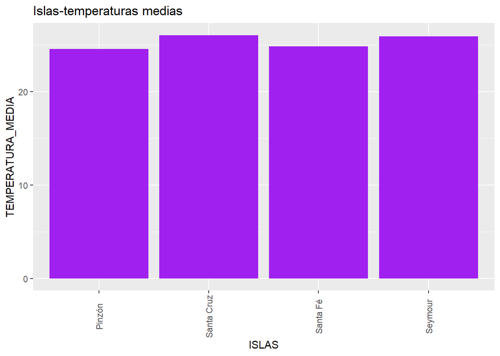

```r
library(ggplot2)

ggplot(data = Tabla_Isla_temperatura, aes(x = `ISLAS`, y = `TEMPERATURA_MEDIA`)) +  geom_bar(stat="identity", position="stack", fill="purple", show.legend = TRUE) + ggtitle("Islas-temperaturas medias")+ theme(axis.text.x = element_text(angle = 90, vjust = 0.5, hjust=0.5))
```